# Unit1-IntrotoAnalytics

Raka

9/21/2020

## Getting started with R: Vector and dataframe

I would like to document all of my learning journey for this specific course on EDX: MITx Analytics Edge, offered to students who are interesting in using R as the data science engine. For those who are interested, go to: https://www.edx.org/course/the-analytics-edge for details.

```r
c(2,5,1,6,3)
```

```
## [1] 2 5 1 6 3
```

```r
country <- c("Brazil", "Indonesia", "China", "USA")
country
```

```
## [1] "Brazil"    "Indonesia" "China"     "USA"
```

```r
lifeExpectancy <- c(78,75,72,81)

# Getting specific element. ex: Indonesia, number 2
country[2]
```

```
## [1] "Indonesia"
```

## Creating sequence of numbers

We can also create a sequence of numbers using seq() function. See below.

```r
seq(0,100,2)
```

```
##  [1]   0   2   4   6   8  10  12  14  16  18  20  22  24  26  28  30  32  34  36
## [20]  38  40  42  44  46  48  50  52  54  56  58  60  62  64  66  68  70  72  74
## [39]  76  78  80  82  84  86  88  90  92  94  96  98 100
```

## Data frame in R

```r
countryData <- data.frame(country, lifeExpectancy)
countryData
```

```
##     country lifeExpectancy
## 1    Brazil             78
## 2 Indonesia             75
## 3     China             72
## 4       USA             81
```

## Adding data into the dataframe

Bear in mind, I just randomly created these numbers without checking their actual values.

```r
countryData$population <- c(10000,22222,64545454,11101)
countryData
```

```
##     country lifeExpectancy population
## 1    Brazil             78      10000
## 2 Indonesia             75      22222
## 3     China             72   64545454
## 4       USA             81      11101
```

## Combining/ appending dataframe

For instance, we have 2 extra countries – to be addded as rows.

```r
country <- c("Switzerland", "France")
lifeExpectancy <- c(88,81)
population <- c(9000000,1191919)

newCountryData <- data.frame(country, lifeExpectancy, population)

# Adding this df to old df
AllCountrydata <- rbind(countryData, newCountryData)
AllCountrydata
```

```
##       country lifeExpectancy population
## 1      Brazil             78      10000
## 2   Indonesia             75      22222
## 3       China             72   64545454
## 4         USA             81      11101
## 5 Switzerland             88    9000000
## 6      France             81    1191919
```

## Reading data from a CSV file

Let’s now read a CSV file in our folder. Check your directory to see the generated file :).

```r
WHO <- read.csv("WHO.csv")
WHO
```

```
##                                       Country                Region Population
## 1                                 Afghanistan Eastern Mediterranean      29825
## 2                                     Albania                Europe       3162
## 3                                     Algeria                Africa      38482
## 4                                     Andorra                Europe         78
## 5                                      Angola                Africa      20821
## 6                         Antigua and Barbuda              Americas         89
## 7                                   Argentina              Americas      41087
## 8                                     Armenia                Europe       2969
## 9                                   Australia       Western Pacific      23050
## 10                                    Austria                Europe       8464
## 11                                 Azerbaijan                Europe       9309
## 12                                    Bahamas              Americas        372
## 13                                    Bahrain Eastern Mediterranean       1318
## 14                                 Bangladesh       South-East Asia     155000
```

[output cut: 765 more lines]

```r
str(WHO)
```

```
## 'data.frame':    194 obs. of  13 variables:
##  $ Country                      : chr  "Afghanistan" "Albania" "Algeria" "Andorra" ...
##  $ Region                       : chr  "Eastern Mediterranean" "Europe" "Africa" "Europe" ...
##  $ Population                   : int  29825 3162 38482 78 20821 89 41087 2969 23050 8464 ...
##  $ Under15                      : num  47.4 21.3 27.4 15.2 47.6 ...
##  $ Over60                       : num  3.82 14.93 7.17 22.86 3.84 ...
##  $ FertilityRate                : num  5.4 1.75 2.83 NA 6.1 2.12 2.2 1.74 1.89 1.44 ...
##  $ LifeExpectancy               : int  60 74 73 82 51 75 76 71 82 81 ...
##  $ ChildMortality               : num  98.5 16.7 20 3.2 163.5 ...
##  $ CellularSubscribers          : num  54.3 96.4 99 75.5 48.4 ...
##  $ LiteracyRate                 : num  NA NA NA NA 70.1 99 97.8 99.6 NA NA ...
##  $ GNI                          : num  1140 8820 8310 NA 5230 ...
##  $ PrimarySchoolEnrollmentMale  : num  NA NA 98.2 78.4 93.1 91.1 NA NA 96.9 NA ...
##  $ PrimarySchoolEnrollmentFemale: num  NA NA 96.4 79.4 78.2 84.5 NA NA 97.5 NA ...
```

```r
# We can even call a summary function
summary(WHO)
```

```
##    Country             Region            Population         Under15
##  Length:194         Length:194         Min.   :      1   Min.   :13.12
##  Class :character   Class :character   1st Qu.:   1696   1st Qu.:18.72
##  Mode  :character   Mode  :character   Median :   7790   Median :28.65
##                                        Mean   :  36360   Mean   :28.73
##                                        3rd Qu.:  24535   3rd Qu.:37.75
##                                        Max.   :1390000   Max.   :49.99
##
##      Over60      FertilityRate   LifeExpectancy  ChildMortality
##  Min.   : 0.81   Min.   :1.260   Min.   :47.00   Min.   :  2.200
##  1st Qu.: 5.20   1st Qu.:1.835   1st Qu.:64.00   1st Qu.:  8.425
##  Median : 8.53   Median :2.400   Median :72.50   Median : 18.600
##  Mean   :11.16   Mean   :2.941   Mean   :70.01   Mean   : 36.149
##  3rd Qu.:16.69   3rd Qu.:3.905   3rd Qu.:76.00   3rd Qu.: 55.975
##  Max.   :31.92   Max.   :7.580   Max.   :83.00   Max.   :181.600
##                  NA's   :11
##  CellularSubscribers  LiteracyRate        GNI
##  Min.   :  2.57      Min.   :31.10   Min.   :  340
##  1st Qu.: 63.57      1st Qu.:71.60   1st Qu.: 2335
##  Median : 97.75      Median :91.80   Median : 7870
##  Mean   : 93.64      Mean   :83.71   Mean   :13321
##  3rd Qu.:120.81      3rd Qu.:97.85   3rd Qu.:17558
##  Max.   :196.41      Max.   :99.80   Max.   :86440
##  NA's   :10          NA's   :91      NA's   :32
##  PrimarySchoolEnrollmentMale PrimarySchoolEnrollmentFemale
##  Min.   : 37.20              Min.   : 32.50
##  1st Qu.: 87.70              1st Qu.: 87.30
##  Median : 94.70              Median : 95.10
##  Mean   : 90.85              Mean   : 89.63
##  3rd Qu.: 98.10              3rd Qu.: 97.90
##  Max.   :100.00              Max.   :100.00
##  NA's   :93                  NA's   :93
```

## Taking only a small subset of DF

```r
WHO_Europe <- subset(WHO, Region == "Europe")
str(WHO_Europe)
```

```
## 'data.frame':    53 obs. of  13 variables:
##  $ Country                      : chr  "Albania" "Andorra" "Armenia" "Austria" ...
##  $ Region                       : chr  "Europe" "Europe" "Europe" "Europe" ...
##  $ Population                   : int  3162 78 2969 8464 9309 9405 11060 3834 7278 4307 ...
##  $ Under15                      : num  21.3 15.2 20.3 14.5 22.2 ...
##  $ Over60                       : num  14.93 22.86 14.06 23.52 8.24 ...
##  $ FertilityRate                : num  1.75 NA 1.74 1.44 1.96 1.47 1.85 1.26 1.51 1.48 ...
##  $ LifeExpectancy               : int  74 82 71 81 71 71 80 76 74 77 ...
##  $ ChildMortality               : num  16.7 3.2 16.4 4 35.2 5.2 4.2 6.7 12.1 4.7 ...
##  $ CellularSubscribers          : num  96.4 75.5 103.6 154.8 108.8 ...
##  $ LiteracyRate                 : num  NA NA 99.6 NA NA NA NA 97.9 NA 98.8 ...
##  $ GNI                          : num  8820 NA 6100 42050 8960 ...
##  $ PrimarySchoolEnrollmentMale  : num  NA 78.4 NA NA 85.3 NA 98.9 86.5 99.3 94.8 ...
##  $ PrimarySchoolEnrollmentFemale: num  NA 79.4 NA NA 84.1 NA 99.2 88.4 99.7 97 ...
```

```r
# Storing this subset into a separate csv
write.csv(WHO_Europe, "WHO_Eur.csv")

# This line is used to check our variables
ls()
```

```
## [1] "AllCountrydata" "country"        "countryData"    "lifeExpectancy"
## [5] "newCountryData" "population"     "WHO"            "WHO_Europe"
```

```r
# We can also remove a specific variable by using rm()
rm(countyrdata) #terribly misspelled
```

# Doing basic data analysis

We can practice some data analysis in this exercise such as mean, etc.

```r
WHO$Under15
```

```
##   [1] 47.42 21.33 27.42 15.20 47.58 25.96 24.42 20.34 18.95 14.51 22.25 21.62
##  [13] 20.16 30.57 18.99 15.10 16.88 34.40 42.95 28.53 35.23 16.35 33.75 24.56
##  [25] 25.75 13.53 45.66 44.20 31.23 43.08 16.37 30.17 40.07 48.52 21.38 17.95
##  [37] 28.03 42.17 42.37 30.61 23.94 41.48 14.98 16.58 17.16 14.56 21.98 45.11
##  [49] 17.66 33.72 25.96 30.53 30.29 31.25 30.62 38.95 43.10 15.69 43.29 28.88
##  [61] 16.42 18.26 38.49 45.90 17.62 13.17 38.59 14.60 26.96 40.80 42.46 41.55
##  [73] 36.77 35.35 35.72 14.62 20.71 29.43 29.27 23.68 40.51 21.54 27.53 14.04
##  [85] 27.78 13.12 34.13 25.46 42.37 30.10 24.90 30.21 35.61 14.57 21.64 36.75
##  [97] 43.06 29.45 15.13 17.46 42.72 45.44 26.65 29.03 47.14 14.98 30.10 40.22
## [109] 20.17 29.02 35.81 18.26 27.05 19.01 27.85 45.38 25.28 36.59 30.10 35.58
## [121] 17.21 20.26 33.37 49.99 44.23 30.61 18.64 24.19 34.31 30.10 28.65 38.37
## [133] 32.78 29.18 34.53 14.91 14.92 13.28 15.25 16.52 15.05 15.45 43.56 25.96
## [145] 24.31 25.70 37.88 14.04 41.60 29.69 43.54 16.45 21.95 41.74 16.48 15.00
## [157] 14.16 40.37 47.35 29.53 42.28 15.20 25.15 41.48 27.83 38.05 16.71 14.79
## [169] 35.35 35.75 18.47 16.89 46.33 41.89 37.33 20.73 23.22 26.00 28.65 30.61
## [181] 48.54 14.18 14.41 17.54 44.85 19.63 22.05 28.90 37.37 28.84 22.87 40.72
## [193] 46.73 40.24
```

```r
mean(WHO$Under15)
```

```
## [1] 28.73242
```

```r
# and std dev

sd(WHO$Under15)
```

```
## [1] 10.53457
```

```r
# or specific variable
summary(WHO$Under15)
```

```
##    Min. 1st Qu.  Median    Mean 3rd Qu.    Max.
##   13.12   18.72   28.65   28.73   37.75   49.99
```

## Can we index to a specific value? YES!

```r
which.min(WHO$Under15)
```

```
## [1] 86
```

```r
which.max(WHO$Under15)
```

```
## [1] 124
```

```r
# Now we use this as indexing

WHO$Country[which.min(WHO$Under15)]
```

```
## [1] "Japan"
```

```r
WHO$Country[which.max(WHO$Under15)]
```

```
## [1] "Niger"
```

## Plotting world in R

So, let’s start with the scatter plot: the mother of all plots.

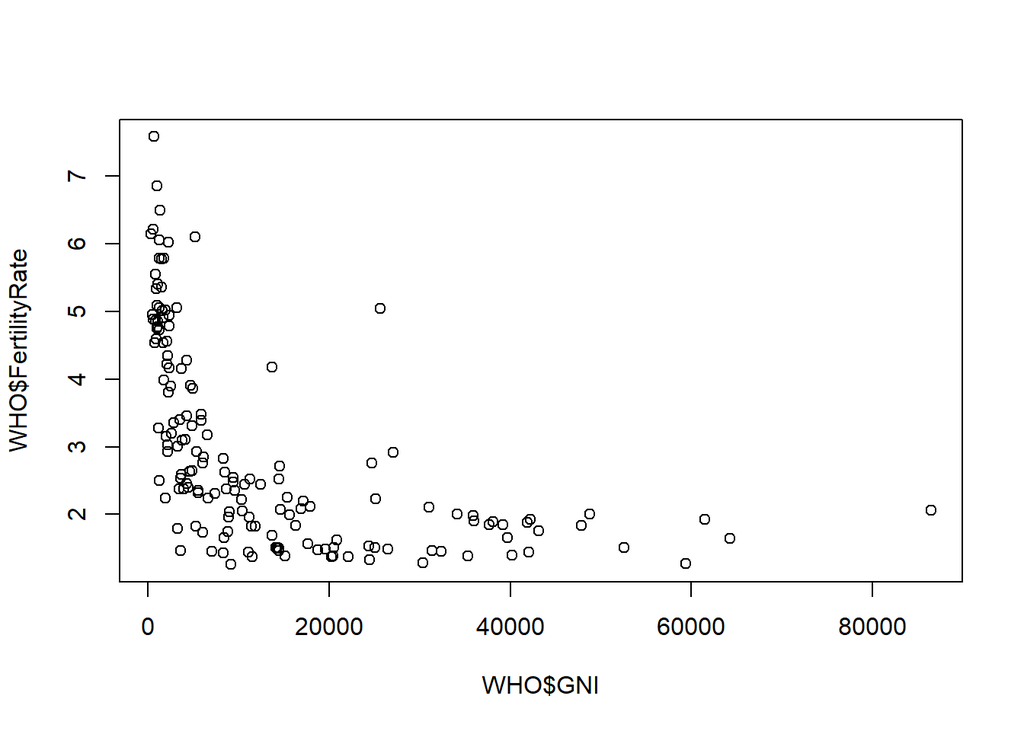

```r
plot(x = WHO$GNI, y = WHO$FertilityRate)
```

## Managing outliers in dataframe, after seeing the plot

Can we spot the outliers from figure above? yep, of course!

```r
outliers <- subset(WHO, GNI > 10000 & FertilityRate > 2.5)
nrow(outliers)
```

```
## [1] 7
```

```r
# Then we output them
outliers[c("Country", "GNI", "FertilityRate")]
```

```
##               Country   GNI FertilityRate
## 23           Botswana 14550          2.71
## 56  Equatorial Guinea 25620          5.04
## 63              Gabon 13740          4.18
## 83             Israel 27110          2.92
## 88         Kazakhstan 11250          2.52
## 131            Panama 14510          2.52
## 150      Saudi Arabia 24700          2.76
```

## Answering some questions on the website

These are just some lines to answer questions after the video. Feel free to skip.

```r
colnames(WHO)
```

```
##  [1] "Country"                       "Region"
##  [3] "Population"                    "Under15"
##  [5] "Over60"                        "FertilityRate"
##  [7] "LifeExpectancy"                "ChildMortality"
##  [9] "CellularSubscribers"           "LiteracyRate"
## [11] "GNI"                           "PrimarySchoolEnrollmentMale"
## [13] "PrimarySchoolEnrollmentFemale"
```

```r
mean(WHO$Over60)
```

```
## [1] 11.16366
```

```r
WHO$Country[which.min(WHO$Over60)]
```

```
## [1] "United Arab Emirates"
```

```r
WHO$Country[which.max(WHO$LiteracyRate)]
```

```
## [1] "Cuba"
```

# Fun parts: Playing with statistical distributions on R.

Here comes the interesting journey in R, how easy it is to build plots (somewhat complex in EXCEL) with only 1 - 2 lines of code. Embrace!

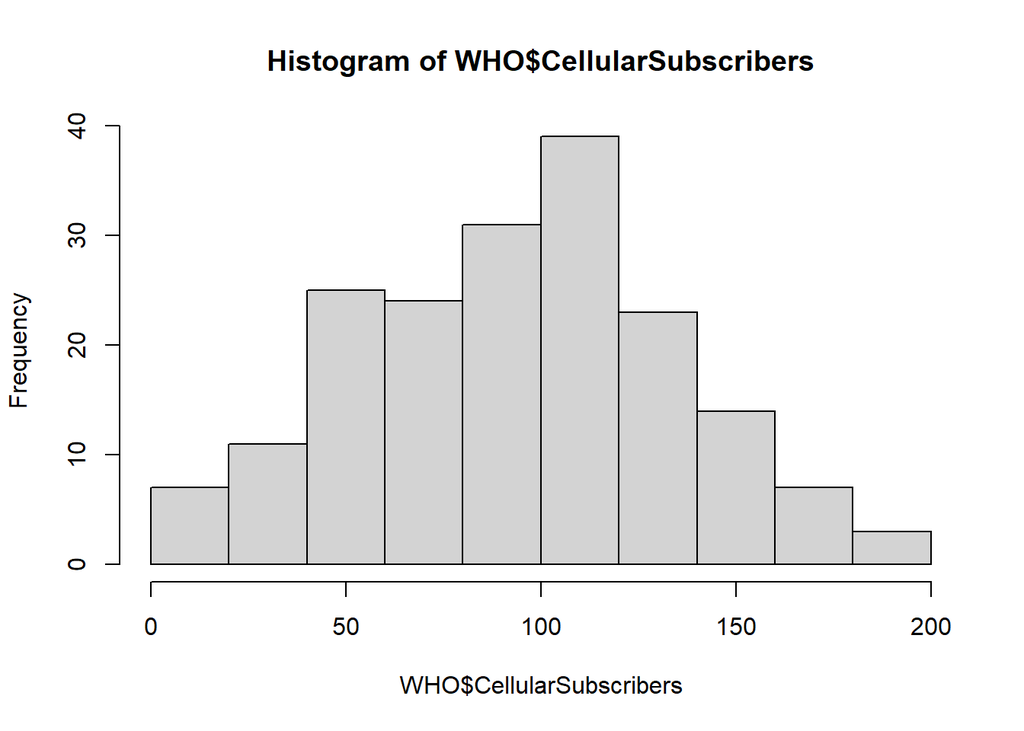

```r
hist(WHO$CellularSubscribers)
```

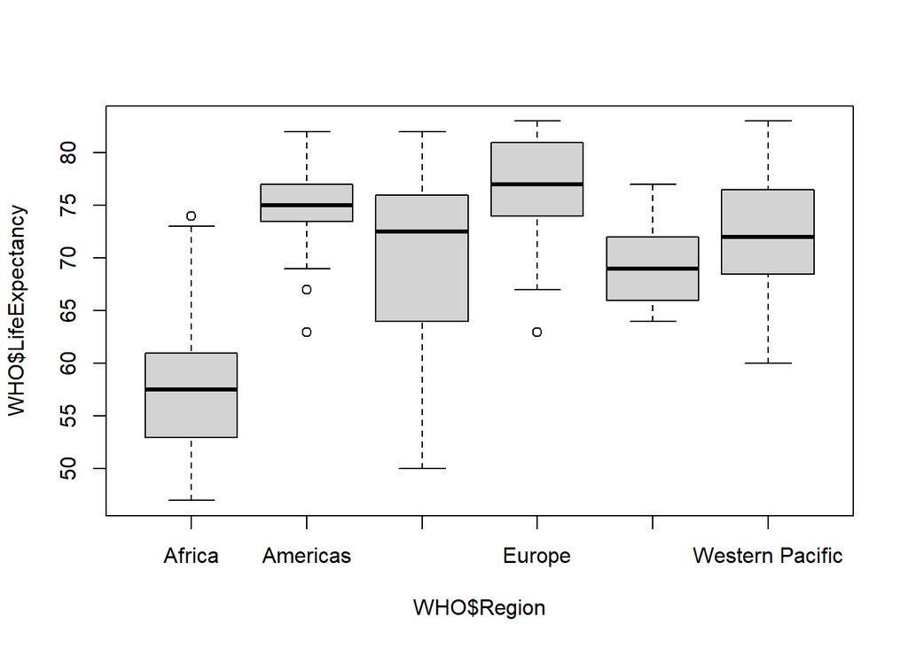

```r
boxplot(WHO$LifeExpectancy ~ WHO$Region)
```

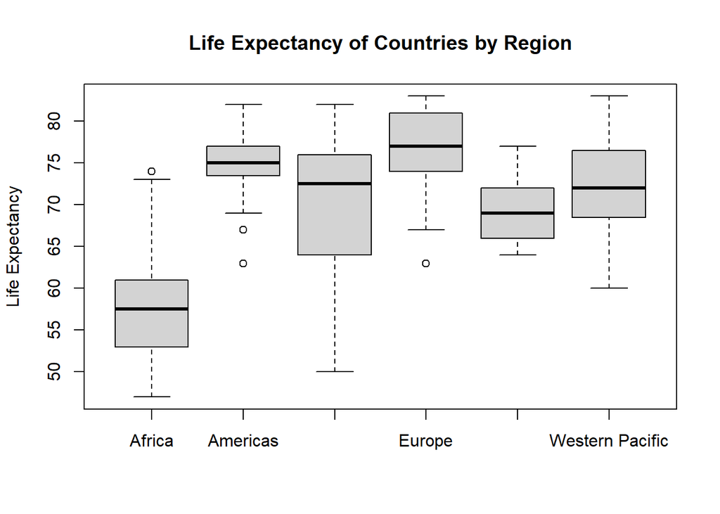

```r
# we fix some labelling and title.
boxplot(WHO$LifeExpectancy ~ WHO$Region,
        xlab = "", ylab = "Life Expectancy",
        main = "Life Expectancy of Countries by Region")
```

# Creating a summary output in a table

We can also create a table from our dataframe as the summary output.

```r
table(WHO$Region)
```

```
##
##                Africa              Americas Eastern Mediterranean
##                    46                    35                    22
##                Europe       South-East Asia       Western Pacific
##                    53                    11                    27
```

# Can we use it to find aggregated results? Ex: the percentage of pop over 60 in these regions. HOW?

Yes, we use the function called tapply :) Behold.

```r
tapply(WHO$Over60, WHO$Region, mean)
```

```
##                Africa              Americas Eastern Mediterranean
##              5.220652             10.943714              5.620000
##                Europe       South-East Asia       Western Pacific
##             19.774906              8.769091             10.162963
```

```r
# Lets then find other results
tapply(WHO$LiteracyRate, WHO$Region, min, na.rm = TRUE)
```

```
##                Africa              Americas Eastern Mediterranean
##                  31.1                  75.2                  63.9
##                Europe       South-East Asia       Western Pacific
##                  95.2                  56.8                  60.6
```

## Answering questions from the course, part 2

If you like, you can skip again this part.

```r
tapply(WHO$ChildMortality, WHO$Region, min, na.rm = TRUE)
```

```
##                Africa              Americas Eastern Mediterranean
##                  13.1                   5.3                   7.4
##                Europe       South-East Asia       Western Pacific
##                   2.2                   9.6                   2.9
```

## The start of Recitation: USDA Nutritional Education, Understanding food

Allright folks, now we enter the recitation part of this week. Are you ready? Yes, I am so pumped too. Let’s get started! Of course, the first thing to do is to load the data

```r
USDA <- read.csv("USDA.csv")

#and somwewhat mandatory steps in any EDA, Str and Summary
str(USDA)
```

```
## 'data.frame':    7058 obs. of  16 variables:
##  $ ID          : int  1001 1002 1003 1004 1005 1006 1007 1008 1009 1010 ...
##  $ Description : chr  "BUTTER,WITH SALT" "BUTTER,WHIPPED,WITH SALT" "BUTTER OIL,ANHYDROUS" "CHEESE,BLUE" ...
##  $ Calories    : int  717 717 876 353 371 334 300 376 403 387 ...
##  $ Protein     : num  0.85 0.85 0.28 21.4 23.24 ...
##  $ TotalFat    : num  81.1 81.1 99.5 28.7 29.7 ...
##  $ Carbohydrate: num  0.06 0.06 0 2.34 2.79 0.45 0.46 3.06 1.28 4.78 ...
##  $ Sodium      : int  714 827 2 1395 560 629 842 690 621 700 ...
##  $ SaturatedFat: num  51.4 50.5 61.9 18.7 18.8 ...
##  $ Cholesterol : int  215 219 256 75 94 100 72 93 105 103 ...
##  $ Sugar       : num  0.06 0.06 0 0.5 0.51 0.45 0.46 NA 0.52 NA ...
##  $ Calcium     : int  24 24 4 528 674 184 388 673 721 643 ...
##  $ Iron        : num  0.02 0.16 0 0.31 0.43 0.5 0.33 0.64 0.68 0.21 ...
##  $ Potassium   : int  24 26 5 256 136 152 187 93 98 95 ...
##  $ VitaminC    : num  0 0 0 0 0 0 0 0 0 0 ...
##  $ VitaminE    : num  2.32 2.32 2.8 0.25 0.26 0.24 0.21 NA 0.29 NA ...
##  $ VitaminD    : num  1.5 1.5 1.8 0.5 0.5 0.5 0.4 NA 0.6 NA ...
```

```r
summary(USDA)
```

```
##        ID        Description           Calories        Protein
##  Min.   : 1001   Length:7058        Min.   :  0.0   Min.   : 0.00
##  1st Qu.: 8387   Class :character   1st Qu.: 85.0   1st Qu.: 2.29
##  Median :13294   Mode  :character   Median :181.0   Median : 8.20
##  Mean   :14260                      Mean   :219.7   Mean   :11.71
##  3rd Qu.:18337                      3rd Qu.:331.0   3rd Qu.:20.43
##  Max.   :93600                      Max.   :902.0   Max.   :88.32
##                                     NA's   :1       NA's   :1
##     TotalFat       Carbohydrate        Sodium         SaturatedFat
##  Min.   :  0.00   Min.   :  0.00   Min.   :    0.0   Min.   : 0.000
##  1st Qu.:  0.72   1st Qu.:  0.00   1st Qu.:   37.0   1st Qu.: 0.172
##  Median :  4.37   Median :  7.13   Median :   79.0   Median : 1.256
##  Mean   : 10.32   Mean   : 20.70   Mean   :  322.1   Mean   : 3.452
##  3rd Qu.: 12.70   3rd Qu.: 28.17   3rd Qu.:  386.0   3rd Qu.: 4.028
##  Max.   :100.00   Max.   :100.00   Max.   :38758.0   Max.   :95.600
##  NA's   :1        NA's   :1        NA's   :84        NA's   :301
##   Cholesterol          Sugar           Calcium             Iron
##  Min.   :   0.00   Min.   : 0.000   Min.   :   0.00   Min.   :  0.000
##  1st Qu.:   0.00   1st Qu.: 0.000   1st Qu.:   9.00   1st Qu.:  0.520
##  Median :   3.00   Median : 1.395   Median :  19.00   Median :  1.330
##  Mean   :  41.55   Mean   : 8.257   Mean   :  73.53   Mean   :  2.828
##  3rd Qu.:  69.00   3rd Qu.: 7.875   3rd Qu.:  56.00   3rd Qu.:  2.620
##  Max.   :3100.00   Max.   :99.800   Max.   :7364.00   Max.   :123.600
##  NA's   :288       NA's   :1910     NA's   :136       NA's   :123
##    Potassium          VitaminC           VitaminE          VitaminD
##  Min.   :    0.0   Min.   :   0.000   Min.   :  0.000   Min.   :  0.0000
##  1st Qu.:  135.0   1st Qu.:   0.000   1st Qu.:  0.120   1st Qu.:  0.0000
##  Median :  250.0   Median :   0.000   Median :  0.270   Median :  0.0000
##  Mean   :  301.4   Mean   :   9.436   Mean   :  1.488   Mean   :  0.5769
##  3rd Qu.:  348.0   3rd Qu.:   3.100   3rd Qu.:  0.710   3rd Qu.:  0.1000
##  Max.   :16500.0   Max.   :2400.000   Max.   :149.400   Max.   :250.0000
##  NA's   :409       NA's   :332        NA's   :2720      NA's   :2834
```

## There is a weird number!

The amount of sodium (max value) that summary function gives us is way too high. Let’s find out what that is.

```r
names(USDA)
```

```
##  [1] "ID"           "Description"  "Calories"     "Protein"      "TotalFat"
##  [6] "Carbohydrate" "Sodium"       "SaturatedFat" "Cholesterol"  "Sugar"
## [11] "Calcium"      "Iron"         "Potassium"    "VitaminC"     "VitaminE"
## [16] "VitaminD"
```

```r
USDA$Description[which.max(USDA$Sodium)]
```

```
## [1] "SALT,TABLE"
```

# What about high containing sodium?

We can create a subset of data, using subset function indeed :)

```r
HiSodium <- subset(USDA, Sodium > 10000)
nrow(HiSodium)
```

```
## [1] 10
```

```r
HiSodium$Description
```

```
##  [1] "SALT,TABLE"
##  [2] "SOUP,BF BROTH OR BOUILLON,PDR,DRY"
##  [3] "SOUP,BEEF BROTH,CUBED,DRY"
##  [4] "SOUP,CHICK BROTH OR BOUILLON,DRY"
##  [5] "SOUP,CHICK BROTH CUBES,DRY"
##  [6] "GRAVY,AU JUS,DRY"
##  [7] "ADOBO FRESCO"
##  [8] "LEAVENING AGENTS,BAKING PDR,DOUBLE-ACTING,NA AL SULFATE"
##  [9] "LEAVENING AGENTS,BAKING SODA"
## [10] "DESSERTS,RENNIN,TABLETS,UNSWTND"
```

## Finding the sodium value of “CAVIAR”

Yes, we can also filter using ‘string’ as input command.

```r
match("CAVIAR", USDA$Description)
```

```
## [1] 4154
```

```r
USDA$Sodium[match("CAVIAR", USDA$Description)]
```

```
## [1] 1500
```

```r
# descriptive stas
mean(USDA$Sodium, na.rm = T)
```

```
## [1] 322.0592
```

```r
sd(USDA$Sodium, na.rm = T)
```

```
## [1] 1045.417
```

## Entering the visualization part of week 1 USDA DATA

Here we go, my favorite part totally!

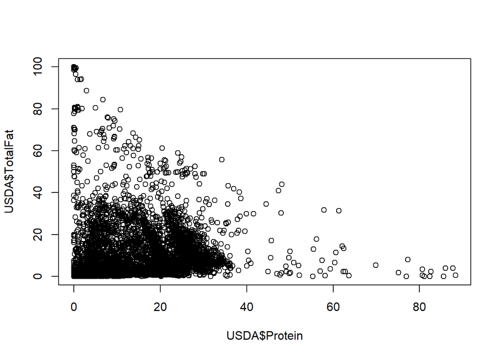

```r
plot(USDA$Protein, USDA$TotalFat)
```

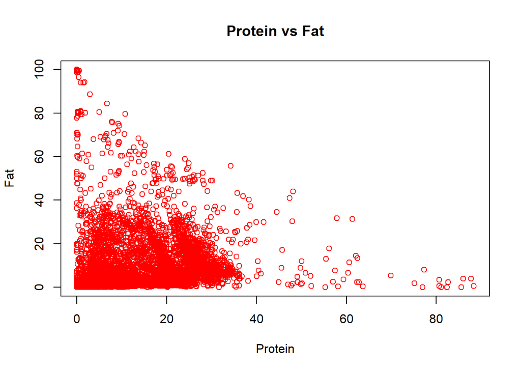

```r
plot(USDA$Protein, USDA$TotalFat, xlab = "Protein", ylab = "Fat",
     main = "Protein vs Fat", col = "red")
```

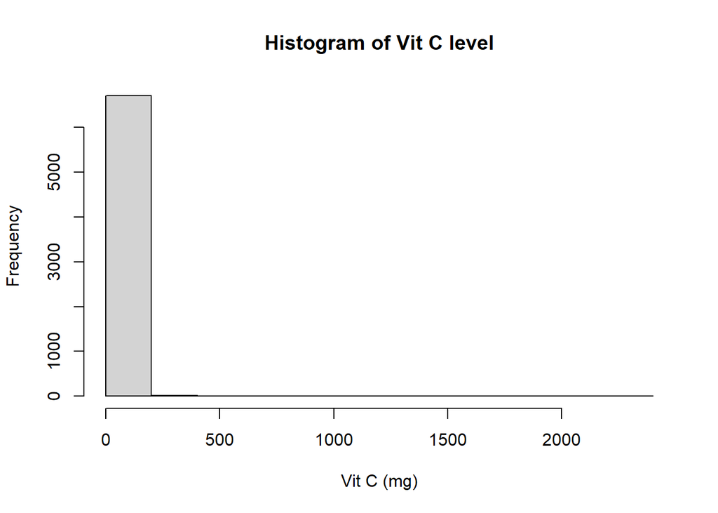

```r
# Histogram of VItC Levels
hist(USDA$VitaminC, xlab = "Vit C (mg)", main = "Histogram of Vit C level")
```

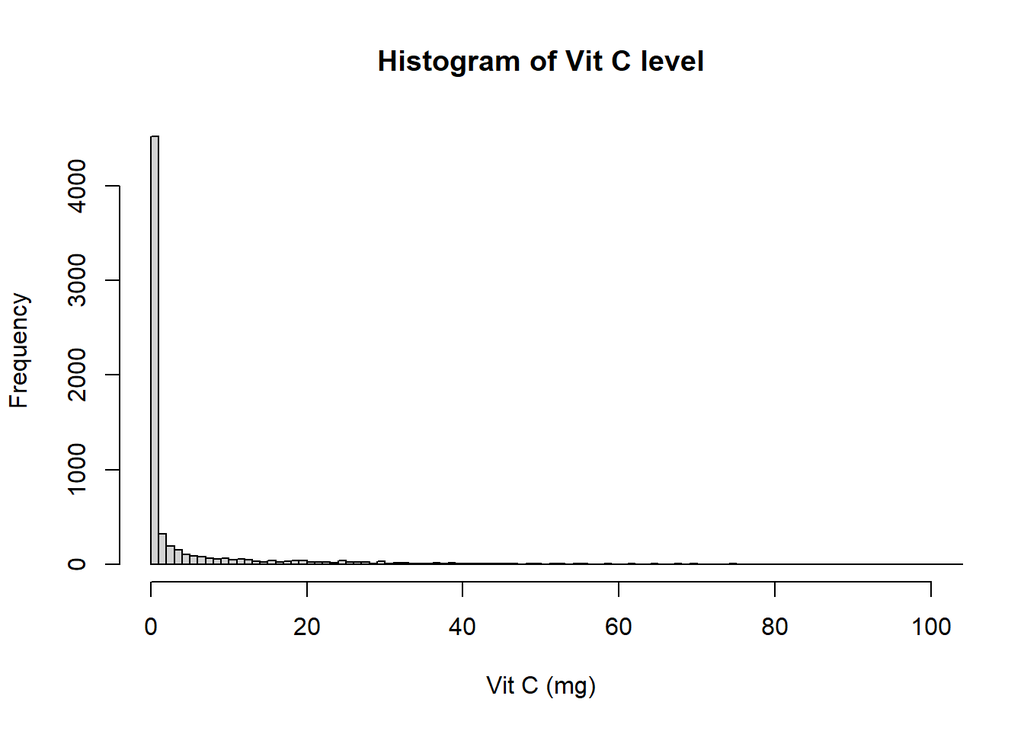

```r
hist(USDA$VitaminC, xlab = "Vit C (mg)", main = "Histogram of Vit C level", xlim = c(0,100), breaks = 2000)
```

## Plotting in boxplot

We look at the sugar level now :)

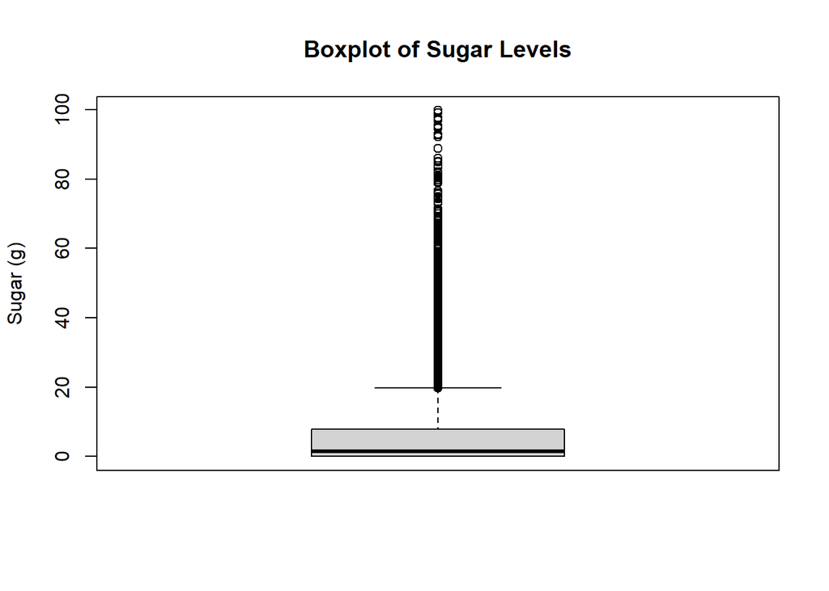

```r
boxplot(USDA$Sugar, main = "Boxplot of Sugar Levels", ylab = "Sugar (g)")
```

## How about creating variables using logical data as results? Sure thing bro

We can assign our logical results as numeric. See below.

```r
HighSodium <- USDA$Sodium > mean(USDA$Sodium, na.rm = TRUE)
HighSodium
```

```
##    [1]  TRUE  TRUE FALSE  TRUE  TRUE  TRUE  TRUE  TRUE  TRUE  TRUE  TRUE  TRUE
##   [13]  TRUE  TRUE  TRUE  TRUE FALSE  TRUE  TRUE  TRUE  TRUE  TRUE  TRUE  TRUE
##   [25]  TRUE  TRUE  TRUE  TRUE  TRUE  TRUE  TRUE  TRUE  TRUE  TRUE  TRUE FALSE
##   [37] FALSE  TRUE  TRUE FALSE  TRUE  TRUE  TRUE  TRUE  TRUE  TRUE  TRUE  TRUE
##   [49] FALSE FALSE FALSE FALSE FALSE FALSE FALSE FALSE FALSE FALSE FALSE FALSE
##   [61] FALSE FALSE FALSE FALSE FALSE FALSE FALSE FALSE FALSE FALSE FALSE FALSE
##   [73] FALSE FALSE FALSE FALSE FALSE FALSE FALSE FALSE FALSE  TRUE  TRUE  TRUE
##   [85]  TRUE  TRUE FALSE FALSE FALSE FALSE FALSE FALSE FALSE FALSE FALSE FALSE
##   [97] FALSE FALSE FALSE FALSE  TRUE FALSE  TRUE FALSE FALSE FALSE FALSE FALSE
##  [109] FALSE FALSE FALSE FALSE FALSE FALSE FALSE FALSE FALSE FALSE FALSE FALSE
##  [121]  TRUE  TRUE  TRUE  TRUE FALSE FALSE FALSE FALSE FALSE  TRUE FALSE  TRUE
##  [133] FALSE FALSE FALSE  TRUE  TRUE  TRUE  TRUE  TRUE  TRUE  TRUE FALSE  TRUE
##  [145]  TRUE  TRUE  TRUE  TRUE FALSE FALSE FALSE  TRUE FALSE FALSE FALSE FALSE
##  [157] FALSE  TRUE FALSE  TRUE  TRUE FALSE  TRUE  TRUE  TRUE  TRUE  TRUE FALSE
##  [169] FALSE FALSE FALSE FALSE FALSE FALSE FALSE FALSE FALSE  TRUE FALSE FALSE
```

[output cut: 574 more lines]

```r
# Assign them as numeric results: 1 or 0

HighSodium <- as.numeric(USDA$Sodium > mean(USDA$Sodium, na.rm = TRUE))
HighSodium
```

```
##    [1]  1  1  0  1  1  1  1  1  1  1  1  1  1  1  1  1  0  1  1  1  1  1  1  1
##   [25]  1  1  1  1  1  1  1  1  1  1  1  0  0  1  1  0  1  1  1  1  1  1  1  1
##   [49]  0  0  0  0  0  0  0  0  0  0  0  0  0  0  0  0  0  0  0  0  0  0  0  0
##   [73]  0  0  0  0  0  0  0  0  0  1  1  1  1  1  0  0  0  0  0  0  0  0  0  0
##   [97]  0  0  0  0  1  0  1  0  0  0  0  0  0  0  0  0  0  0  0  0  0  0  0  0
##  [121]  1  1  1  1  0  0  0  0  0  1  0  1  0  0  0  1  1  1  1  1  1  1  0  1
##  [145]  1  1  1  1  0  0  0  1  0  0  0  0  0  1  0  1  1  0  1  1  1  1  1  0
##  [169]  0  0  0  0  0  0  0  0  0  1  0  0  1  1  1  0  1  0  1  0  0  0  0  0
##  [193]  0  0  1  0  0  0  1  1  1  0  0  0  0  0  0  0  0  0  0  0  0  0  1  1
##  [217]  1  1  1  0  0  0  0  0  0  0  0  1  0  0  0  0  0  0  0  0  0  0  0  0
##  [241]  0  0  0  0  0  0  0  1  0  0  0  0  0  0  0  0  0  0  0  0  0  0  0  1
##  [265]  1  0  0  0  0  0  0  1  0  0  0  0  1  0  0  1  0  0  0  0  0  0  0  0
##  [289]  0  0  1  1  1  1  1  1  1  1  1  1  1  1  1  1  1  1  1  0  0  0  0  0
##  [313]  0  0  0  0  0  0  1  1  1  1  1  1  0  0  0  0  0  0  1  1  0  0  0  0
##  [337]  0  0  0  0  0  0  0  0  0  0  0  0  0  0  0  1  0  0  0  0  0  0  0  0
```

[output cut: 280 more lines]

```r
# Then insert this into a new column
USDA$HiSodium <- as.numeric(USDA$Sodium > mean(USDA$Sodium, na.rm = TRUE))
str(USDA)
```

```
## 'data.frame':    7058 obs. of  17 variables:
##  $ ID          : int  1001 1002 1003 1004 1005 1006 1007 1008 1009 1010 ...
##  $ Description : chr  "BUTTER,WITH SALT" "BUTTER,WHIPPED,WITH SALT" "BUTTER OIL,ANHYDROUS" "CHEESE,BLUE" ...
##  $ Calories    : int  717 717 876 353 371 334 300 376 403 387 ...
##  $ Protein     : num  0.85 0.85 0.28 21.4 23.24 ...
##  $ TotalFat    : num  81.1 81.1 99.5 28.7 29.7 ...
##  $ Carbohydrate: num  0.06 0.06 0 2.34 2.79 0.45 0.46 3.06 1.28 4.78 ...
##  $ Sodium      : int  714 827 2 1395 560 629 842 690 621 700 ...
##  $ SaturatedFat: num  51.4 50.5 61.9 18.7 18.8 ...
##  $ Cholesterol : int  215 219 256 75 94 100 72 93 105 103 ...
##  $ Sugar       : num  0.06 0.06 0 0.5 0.51 0.45 0.46 NA 0.52 NA ...
##  $ Calcium     : int  24 24 4 528 674 184 388 673 721 643 ...
##  $ Iron        : num  0.02 0.16 0 0.31 0.43 0.5 0.33 0.64 0.68 0.21 ...
##  $ Potassium   : int  24 26 5 256 136 152 187 93 98 95 ...
##  $ VitaminC    : num  0 0 0 0 0 0 0 0 0 0 ...
##  $ VitaminE    : num  2.32 2.32 2.8 0.25 0.26 0.24 0.21 NA 0.29 NA ...
##  $ VitaminD    : num  1.5 1.5 1.8 0.5 0.5 0.5 0.4 NA 0.6 NA ...
##  $ HiSodium    : num  1 1 0 1 1 1 1 1 1 1 ...
```

```r
# and do the same for other variables
USDA$HiProtein <- as.numeric(USDA$Protein > mean(USDA$Protein, na.rm = TRUE))
USDA$HiFat <- as.numeric(USDA$TotalFat > mean(USDA$TotalFat, na.rm = TRUE))
USDA$HiCarbs <- as.numeric(USDA$Carbohydrate > mean(USDA$Carbohydrate, na.rm = TRUE))
str(USDA)
```

```
## 'data.frame':    7058 obs. of  20 variables:
##  $ ID          : int  1001 1002 1003 1004 1005 1006 1007 1008 1009 1010 ...
##  $ Description : chr  "BUTTER,WITH SALT" "BUTTER,WHIPPED,WITH SALT" "BUTTER OIL,ANHYDROUS" "CHEESE,BLUE" ...
##  $ Calories    : int  717 717 876 353 371 334 300 376 403 387 ...
##  $ Protein     : num  0.85 0.85 0.28 21.4 23.24 ...
##  $ TotalFat    : num  81.1 81.1 99.5 28.7 29.7 ...
##  $ Carbohydrate: num  0.06 0.06 0 2.34 2.79 0.45 0.46 3.06 1.28 4.78 ...
##  $ Sodium      : int  714 827 2 1395 560 629 842 690 621 700 ...
##  $ SaturatedFat: num  51.4 50.5 61.9 18.7 18.8 ...
##  $ Cholesterol : int  215 219 256 75 94 100 72 93 105 103 ...
##  $ Sugar       : num  0.06 0.06 0 0.5 0.51 0.45 0.46 NA 0.52 NA ...
##  $ Calcium     : int  24 24 4 528 674 184 388 673 721 643 ...
##  $ Iron        : num  0.02 0.16 0 0.31 0.43 0.5 0.33 0.64 0.68 0.21 ...
##  $ Potassium   : int  24 26 5 256 136 152 187 93 98 95 ...
##  $ VitaminC    : num  0 0 0 0 0 0 0 0 0 0 ...
##  $ VitaminE    : num  2.32 2.32 2.8 0.25 0.26 0.24 0.21 NA 0.29 NA ...
##  $ VitaminD    : num  1.5 1.5 1.8 0.5 0.5 0.5 0.4 NA 0.6 NA ...
##  $ HiSodium    : num  1 1 0 1 1 1 1 1 1 1 ...
##  $ HiProtein   : num  0 0 0 1 1 1 1 1 1 1 ...
##  $ HiFat       : num  1 1 1 1 1 1 1 1 1 1 ...
##  $ HiCarbs     : num  0 0 0 0 0 0 0 0 0 0 ...
```

## Creating a summary table from our previous results

We can now summarize our analysis and present them in a chart.

```r
table(USDA$HiSodium, USDA$HiFat)
```

```
##
##        0    1
##   0 3529 1355
##   1 1378  712
```

## Looking for specifics: Food that contains iron, can we calculate their average iron contents based on two groups of Hi Protein?

Yes, why not! We use tapply for that.

```r
tapply(USDA$Iron, USDA$HiProtein, mean, na.rm = TRUE)
```

```
##        0        1
## 2.558945 3.197294
```

```r
# With the same approach, to find max vit C between hi carb/ lo carb food
tapply(USDA$VitaminC , USDA$HiCarbs, max, na.rm = TRUE)
```

```
##      0      1
## 1677.6 2400.0
```

```r
# we can even use summary!
tapply(USDA$VitaminC , USDA$HiCarbs, summary, na.rm = TRUE)
```

```
## $`0`
##     Min.  1st Qu.   Median     Mean  3rd Qu.     Max.     NA's
##    0.000    0.000    0.000    6.364    2.800 1677.600      248
##
## $`1`
##    Min. 1st Qu.  Median    Mean 3rd Qu.    Max.    NA's
##    0.00    0.00    0.20   16.31    4.50 2400.00      83
```